# Case study A: Exploring scRNA-seq data from 5 cancer cell lines with scBubbletree

### Compositional plots

`scBubbletree` uses the R-package `patchwork` to combine `ggplot2` and `ggtree` plots. This makes it convenient for users to ‘attach’ other plots that are generated by any of these package.

[figure not shown]

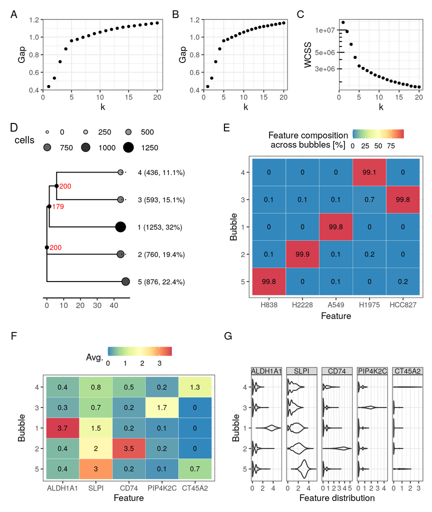

### Are local/global distances between cells preserved by UMAP/t-SNE?

local = yes; long-range = no

```r
# C = vector clusters of points
get_d <- function(A, U_A, T_A, C, tree_dist, B, verbose=F) {

  get_euc <- function(x, y) {
    return(sqrt(sum((x-y)^2)))
  }

  get_pair_euc <- function(x, A, U_A, T_A, C, tree_dist) {

    if(x %% 1000 == 0) {
      cat(x, "\n")
    }

    j <- sample(x = 1:nrow(A), size = 2, replace = T)
    a_euc <- get_euc(A[j[1],], A[j[2],])
    u_euc <- get_euc(U_A[j[1],], U_A[j[2],])
    t_euc <- get_euc(T_A[j[1],], T_A[j[2],])
    t_dist <- tree_dist[C[j[1]],C[j[2]]]

    return(data.frame(a_euc = a_euc,
                      u_euc = u_euc,
                      t_euc = t_euc,
                      tree_dist = t_dist,
                      i = j[1],
                      j = j[2]))
  }

  o <- lapply(X = 1:B,
              FUN = get_pair_euc,
              A = A,
              U_A = U_A,
              T_A = T_A,
              C = C,
              tree_dist = tree_dist)

  o <- do.call(rbind, o)
  return(o)
}
```

```r
pair_dist <- get_d(B = 5*10^4,
                   A = A,
                   U_A = umap_data[, c("UMAP_1", "UMAP_2")],
                   T_A = tsne_data[, c("tSNE_1", "tSNE_2")],
                   C = k5$cluster,
                   tree_dist = acast(data = k5$pair_dist$hc_pair_dist,
                                     formula = c_i~c_j,
                                     value.var = "M"),
                   verbose = T)

pair_dist$i_cell <- meta$cell_line_demuxlet[pair_dist$i]
pair_dist$j_cell <- meta$cell_line_demuxlet[pair_dist$j]
pair_dist$comparison <- ifelse(test = pair_dist$i_cell==pair_dist$j_cell,
                               yes = "w", no = "b")
```

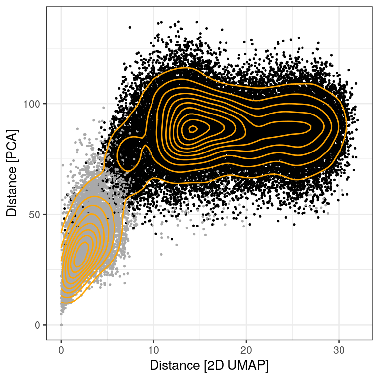

```r
g_pairs_umap <- ggplot(data = pair_dist)+
  geom_point(aes(y = a_euc, x = u_euc, col = comparison), size = 0.25)+
  geom_density_2d(aes(y = a_euc, x = u_euc), col = "orange")+
  ylab(label = "Distance [PCA]")+
  xlab(label = "Distance [2D UMAP]")+
  scale_color_manual(values = c("black", "darkgray"))+
  theme(legend.position = "none")

g_pairs_umap
```

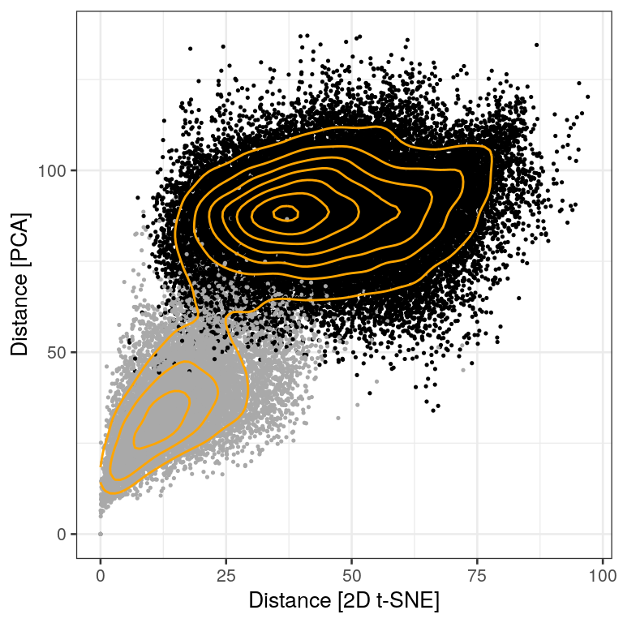

```r
g_pairs_tsne <- ggplot(data = pair_dist)+
  geom_point(aes(y = a_euc, x = t_euc, col = comparison), size = 0.25)+
  geom_density_2d(aes(y = a_euc, x = t_euc), col = "orange")+
  ylab(label = "Distance [PCA]")+
  xlab(label = "Distance [2D t-SNE]")+
  scale_color_manual(values = c("black", "darkgray"))+
  theme(legend.position = "none")

g_pairs_tsne
```

### Benchmarking: k-means, 2D UMAP/tSNE

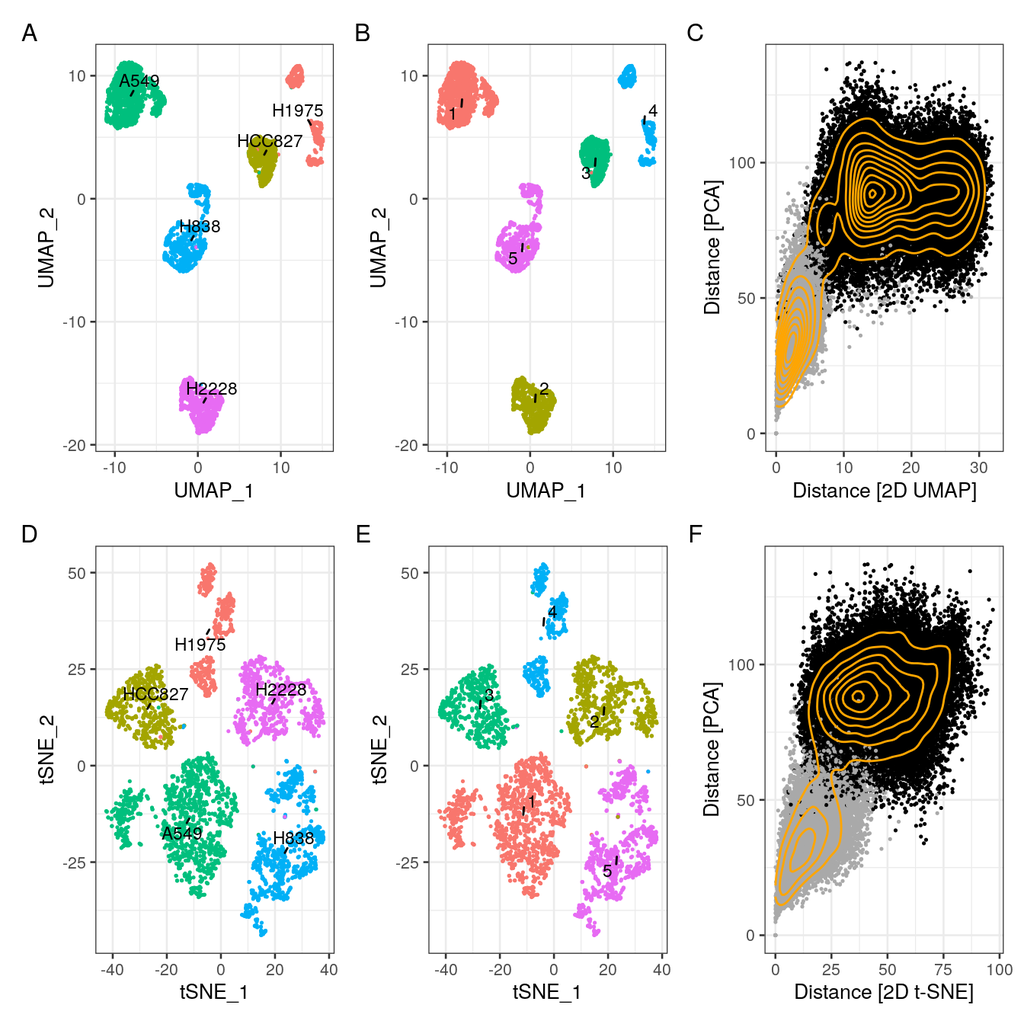

```r
umap_data$k <- k5$cluster
tsne_data$k <- k5$cluster

umap_k_centers <- merge(x = aggregate(UMAP_1~k, data = umap_data, FUN = median),
                      y = aggregate(UMAP_2~k, data = umap_data, FUN = median),
                      by = "k")
tsne_k_centers <- merge(x = aggregate(tSNE_1~k, data = tsne_data, FUN = median),
                      y = aggregate(tSNE_2~k, data = tsne_data, FUN = median),
                      by = "k")

g_clustering<-((ggplot()+
  geom_point(data = umap_data,
             aes(x = UMAP_1, y = UMAP_2, col = cell_line_demuxlet), size = 0.25)+
  geom_text_repel(data = umap_centers,
            aes(x = UMAP_1, y = UMAP_2, label = cell_line_demuxlet),
            col = "black", min.segment.length = 0, force = 10, size = 3)+
  theme(legend.position = "none")+
    scale_color_manual(name = "cell line", values = c("H1975"="#F8766D",
                                                    "HCC827"="#A3A500",
                                                    "A549"="#00BF7D",
                                                    "H838"="#00B0F6",
                                                    "H2228"="#E76BF3"))+
  guides(colour = guide_legend(nrow = 2, override.aes = list(size=2))))|
(ggplot()+
  geom_point(data = umap_data,
             aes(x = UMAP_1, y = UMAP_2, col = as.character(k)), size = 0.25)+
  geom_text_repel(data = umap_k_centers,
            aes(x = UMAP_1, y = UMAP_2, label = as.character(k)),
            min.segment.length = 0, size = 3)+
  theme(legend.position = "none")+
    scale_color_manual(name = "cluster", values = c("1"="#F8766D",
                                                    "2"="#A3A500",
                                                    "3"="#00BF7D",
                                                    "4"="#00B0F6",
                                                    "5"="#E76BF3"))+
  guides(colour = guide_legend(nrow = 2, override.aes = list(size=2))))|g_pairs_umap)/
((ggplot()+
  geom_point(data = tsne_data,
             aes(x = tSNE_1, y = tSNE_2, col = cell_line_demuxlet), size = 0.25)+
  geom_text_repel(data = tsne_centers,
            aes(x = tSNE_1, y = tSNE_2, label = cell_line_demuxlet),
            col = "black", min.segment.length = 0, force = 10, size = 3)+
  theme(legend.position = "none")+
    scale_color_manual(name = "cell line", values = c("H1975"="#F8766D",
                                                    "HCC827"="#A3A500",
                                                    "A549"="#00BF7D",
                                                    "H838"="#00B0F6",
                                                    "H2228"="#E76BF3"))+
  guides(colour = guide_legend(nrow = 2, override.aes = list(size=2))))|
(ggplot()+
  geom_point(data = tsne_data,
             aes(x = tSNE_1, y = tSNE_2, col = as.character(k)), size = 0.25)+
  geom_text_repel(data = tsne_k_centers,
            aes(x = tSNE_1, y = tSNE_2, label = as.character(k)),
            min.segment.length = 0, size = 3)+
  theme(legend.position = "none")+
    scale_color_manual(name = "cluster", values = c("1"="#F8766D",
                                                    "2"="#A3A500",
                                                    "3"="#00BF7D",
                                                    "4"="#00B0F6",
                                                    "5"="#E76BF3"))+
  guides(colour = guide_legend(nrow = 2, override.aes = list(size=2))))|
  g_pairs_tsne)

g_clustering <- g_clustering+patchwork::plot_annotation(tag_level = 'A')
g_clustering
```

```r
ggsave(plot = g_clustering,
       filename = "manuscript_data/Supplement_case_study_A.png",
       device = "png",
       width = 6.5,
       height = 5.5,
       dpi = 600)
```

### scBubbletree can incorporate clustering results from approaches

Wide range of clustering approaches are used to cluster scRNA-seq data. To accommodate for this `scBubbletree` implements the function `dummy_bubbletree` which can generate a bubbletree using segmentation of alternative approaches.

Lets do this using k-medoids clustering implemented as part of the R-package cluster:

```r
pam_k5 <- cluster::pam(x = A, k = 5, metric = "euclidean")

dummy_k5 <- dummy_bubbletree(x = A,
                             cs = pam_k5$clustering,
                             B = 100,
                             N_eff = 100,
                             cores = 2,
                             round_digits = 1)
```

```
FALSE Generating bubbletree ...
```

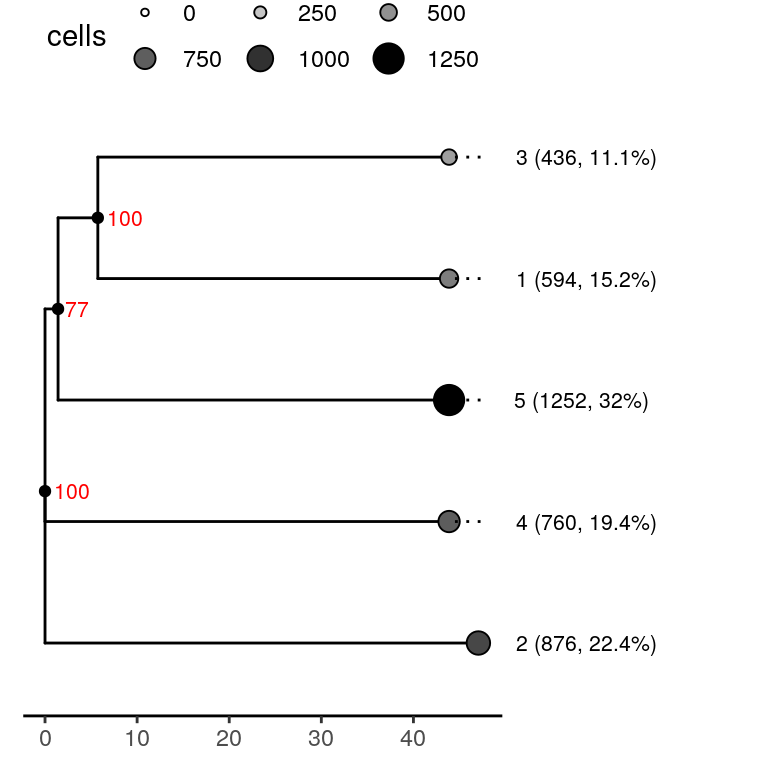

```r
dummy_k5$tree
```

## In-depth inspection of sets of bubbles

Imagine a branch of bubbles (or even a single bubble) in the bubbletree that is of particular interest to us. We might want to have a more in-depth look into the substructre structure of that bubble. `scBubbletree` provides the function `update_bubbletree` which allows you to perform additional clustering over specific set of bubbles and to update the original bubbletree.

*Caveat:* this function was implemented to help the user gain better understanding of the data. It is important to note that the final clustering solution obtained with this function is not necessarily the optimal clustering solution, i.e. clustering with global minimum within cluster sum of squares.

[output not shown]

Notice the new 6 bubbles with names 1_A to 1_F. The prefix 1 stands for the updating iteration, i.e. if we performed an additional updating of u_k5, then the new bubble names would start with prefix 2.

We should further inspect each of the new bubbles to try and understand whether they carry some distinguishing biological features. As case study A deals with a toy dataset this updating analysis is not necessary, however, when analyzing more complex datasets (e.g. see case study B) having the ability to zoom into clades or bubbles can be extremely beneficial and revealing.

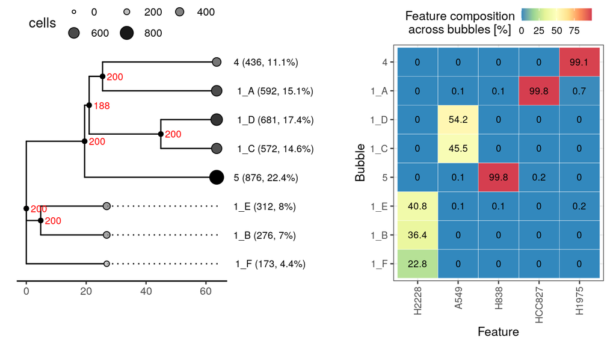

```r
u_w1 <- get_cat_feature_tiles(d = u_k5,
                              a = d@meta.data$cell_line_demuxlet,
                              integrate_vertical = T,
                              round_digits = 1,
                              tile_text_size = 2.75,
                              rotate_x_axis = T)

(u_k5$tree|u_w1$w)+
  patchwork::plot_layout(ncol = 2, widths = c(1, 1))
```

### Summary

`scBubbletree` promote simple and transparent analysis of scRNA-seq. It is *not a black-box* approach and the user *is encouraged* to explore the data with different values of `k`. At each stage the user should ‘attach’ annotation to the bubbletree for biological interpretation of the different bubbles and their relationships that are encoded by the bubbletree topology.

### References

[^1]: Tian, Luyi, et al. “Benchmarking single cell RNA-sequencing analysis pipelines using mixture control experiments.” Nature methods 16.6 (2019): 479-487.